# "Iris flowers" shiny app

Marcella Lai  
02 August 2019

### "Iris flowers" : summary

This presentation pitch the “Iris flowers” application you could find [here](https://marcella.shinyapps.io/myShinyApp-DDPW4_2/)

The data used is “iris” data set (standard R packages) It contains features measured for 3 Iris species, setosa, virginica, versicolor ; it's an example of multivariate data set introduced by Ronald Fisher in 1936.

“Iris flowers” uses a linear regression model showing correlation between petal height and its width. “Iris flowers” application allows users

- to select what species investigate ( ALL species or just one)
- to know the related value of value of slope of regression model Application draws plot of iris data set distributed by height (x axis) and weight (y axis) and the regression line.

### "Iris flowers" : details on data

The data used is “iris” data set, available with standard R packages. Data set consists of 4 measurements (length and width of the petals and sepals) for 3 species of iris : 50 observations for each species, 150 in total.

```r
summary(iris)
```

```
  Sepal.Length    Sepal.Width     Petal.Length    Petal.Width
 Min.   :4.300   Min.   :2.000   Min.   :1.000   Min.   :0.100
 1st Qu.:5.100   1st Qu.:2.800   1st Qu.:1.600   1st Qu.:0.300
 Median :5.800   Median :3.000   Median :4.350   Median :1.300
 Mean   :5.843   Mean   :3.057   Mean   :3.758   Mean   :1.199
 3rd Qu.:6.400   3rd Qu.:3.300   3rd Qu.:5.100   3rd Qu.:1.800
 Max.   :7.900   Max.   :4.400   Max.   :6.900   Max.   :2.500
       Species
 setosa    :50
 versicolor:50
 virginica :50
```

### "Iris flowers" : shiny files

The application is build using Shiny package and the source code is in 2 files: “ui.R” and “server.R” (they can be found here: GitHub [repository](https://github.com/marcellalai/Developing-Data-Products_2/tree/marcellalai-patch-1))

Following some extract from code

```r
      irisInput <- input$inRadioButton
      if (irisInput != "ALL"){
          irisData <- subset(iris, Species == irisInput)
           modelLM <- lm(irisData$Petal.Width ~ irisData$Petal.Length, data = irisData)
            plot(irisData$Petal.Length, irisData$Petal.Width , xlab = "Petal Length in cm", ylab = "Petal Width in cm", bty = "n", pch=21, main = paste("Iris Species - linear regression model for", irisInput, sep=" "))
          abline(modelLM, col = "red" ,lty= 2  , lwd=3)
        ...
```

### "Iris flowers" : just some examples

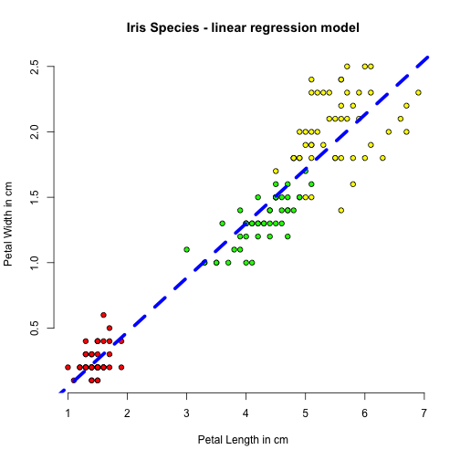

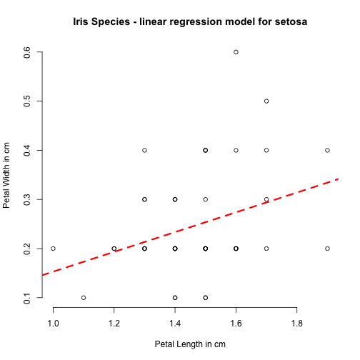